# Machine Learning

##### Aggregation

- Aggregation is performing the same operation on a number of things.
- Regarding methods like `sum()`: use Python's methods on Python datatypes and use NumPy's methods on NumPy arrays (`np.sum()`).

```python
massive_array = np.random.random(100000)
massive_array.size
```

```
100000
```

```python
massive_array[:100]
```

```
array([0.44201532, 0.85263492, 0.43343897, 0.82687037, 0.50934207,
       0.08637698, 0.66003986, 0.20659461, 0.84727532, 0.68135913,
       0.17836735, 0.06985902, 0.00968817, 0.89204966, 0.13346521,
       0.77919197, 0.92516343, 0.71517875, 0.49081861, 0.4694983 ,
       0.88270929, 0.48841006, 0.41456749, 0.17411195, 0.47528944,
       0.78364797, 0.55642943, 0.15986708, 0.14382937, 0.64946303,
       0.5392236 , 0.32568477, 0.14701389, 0.15987007, 0.12941234,
       0.57892239, 0.09226017, 0.91054472, 0.08297175, 0.80037846,
       0.87713097, 0.09345946, 0.42630588, 0.47322067, 0.58019711,
       0.71624417, 0.02706898, 0.73139734, 0.76696351, 0.00976644,
       0.30828617, 0.23286547, 0.50342743, 0.95372138, 0.5578113 ,
       0.09746869, 0.62167849, 0.86302262, 0.15763228, 0.99242952,
       0.08500107, 0.09445791, 0.63360789, 0.94929747, 0.93674647,
       0.44737829, 0.72769634, 0.74223798, 0.30698606, 0.11977135,
       0.44387868, 0.39177432, 0.53184918, 0.84535768, 0.53627454,
       0.68027015, 0.60917758, 0.098478  , 0.09202759, 0.05596583,
       0.08653249, 0.23717329, 0.83951297, 0.52237053, 0.51307486,
       0.64983197, 0.54459088, 0.0324653 , 0.58015172, 0.77108905,
       0.37622657, 0.49102474, 0.98163968, 0.24465141, 0.3743232 ,
       0.04565964, 0.31006764, 0.8315194 , 0.80702284, 0.64002416])
```

```python
%timeit sum(massive_array) #python's sum
```

```
5.24 ms ± 1.18 ms per loop (mean ± std. dev. of 7 runs, 10 loops each)
```

```python
%timeit np.sum(massive_array) #numpy's sum
```

```
27.5 μs ± 2.47 μs per loop (mean ± std. dev. of 7 runs, 10,000 loops each)
```

```python
a2
```

```
array([[[1],
        [2],
        [3]],

       [[4],
        [5],
        [6]]])
```

```python
np.mean(a2)
```

```
np.float64(3.5)
```

```python
np.max(a2)
```

```
np.int64(6)
```

```python
np.min(a2)
```

```
np.int64(1)
```

```python
#Standard Deviation: a measure of how spread out a group of numbers is from the mean
np.std(a2)
```

```
np.float64(1.707825127659933)
```

```python
#Variance = measure of the average degree to which each number is different to the mean
#Higher variences = wider range of numbers
#Lower variance = lower range of numbers
np.var(a2)
```

```
np.float64(2.9166666666666665)
```

```python
np.sqrt(np.var(a2)) #standard deviation = square root of variance
```

```
np.float64(1.707825127659933)
```

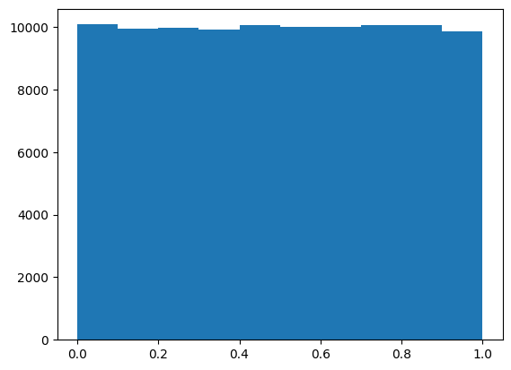

```python
%matplotlib inline
import matplotlib.pyplot as plt
plt.hist(massive_array)
```

##### Reshaping and Transposing

- Reshaping is changing the shape of an array.
- Transposing is switching the axis of an array.
- When operating on tow arrays, NumPy compares their shapes element-wise. It starts with the trailing dimensions and works it was forward. Two dimensions are compatible when:
1. They are equal or
2. One of them is 1.

```python
#Reshaping
a2_new = np.random.randint(10, size=(2,3))
a2_new.shape
```

```
(2, 3)
```

```python
a2_new
```

```
array([[0, 7, 8],
       [9, 4, 9]])
```

```python
a3
```

```
array([[[ 1,  2,  3],
        [ 4,  5,  6],
        [ 7,  8,  9]],

       [[10, 11, 12],
        [13, 14, 15],
        [16, 17, 18]]])
```

```python
a3.shape
```

```
(2, 3, 3)
```

```python
#a2_new*a3

## How can we reshape a2_new to be compatible with a3
```

```python
#reshape a2_new to be compatible with a3
a2_new.reshape(2,3,1)
```

```
array([[[0],
        [7],
        [8]],

       [[9],
        [4],
        [9]]])
```

```python
#So to create the a2_new as the same shape as a3, we need to create a new a2_new matrice
a2_new_reshape = a2_new.reshape(2,3,1)
```

```python
a2_new_reshape * a3
```

```
array([[[  0,   0,   0],
        [ 28,  35,  42],
        [ 56,  64,  72]],

       [[ 90,  99, 108],
        [ 52,  56,  60],
        [144, 153, 162]]])
```

- So we use reshape when we have a mismatch in the number of elements in the arrays.

```python
#Transpose - switches the axis
a2_new.T
```

```
array([[0, 9],
       [7, 4],
       [8, 9]])
```

```python
a2_new.T.shape
```

```
(3, 2)
```

```python
a3
```

```
array([[[ 1,  2,  3],
        [ 4,  5,  6],
        [ 7,  8,  9]],

       [[10, 11, 12],
        [13, 14, 15],
        [16, 17, 18]]])
```

```python
a3.T
```

```
array([[[ 1, 10],
        [ 4, 13],
        [ 7, 16]],

       [[ 2, 11],
        [ 5, 14],
        [ 8, 17]],

       [[ 3, 12],
        [ 6, 15],
        [ 9, 18]]])
```

- The important difference here between transpose and reshape if that transpose just flips the axes around, while reshape changes the (custom) shape of the array.

##### Dot Product and Element-Wise

- One of the main use cases for transposing a matrix is the DOT product.

```python
np.random.seed(0)
mat1 = np.random.randint(10, size=(5,3))
mat2 = np.random.randint(10, size=(5,3))

mat1
```

```
array([[5, 0, 3],
       [3, 7, 9],
       [3, 5, 2],
       [4, 7, 6],
       [8, 8, 1]])
```

```python
mat2
```

```
array([[6, 7, 7],
       [8, 1, 5],
       [9, 8, 9],
       [4, 3, 0],
       [3, 5, 0]])
```

```python
#Element-Wise Multiplication
mat1 * mat2
```

```
array([[30,  0, 21],
       [24,  7, 45],
       [27, 40, 18],
       [16, 21,  0],
       [24, 40,  0]])
```

- For the dot product to happen. The numbers on the inside must match. For example, if there is a 3x3 and one 3x2 matrix. The 3s must match.
- So for a dot product to happen between two matrices, the inner dimensions must match. And the resulting matrix will have the shape of the outer dimensions.

```python
#Dot Product
#np.dot(mat1, mat2)

# #this will give an error because the shapes are not compatible since the numbers on the inside of the matrices are not matching
```

```python
#we will transpose mat1 to make the shapes compatible
mat1.T
```

```
array([[5, 3, 3, 4, 8],
       [0, 7, 5, 7, 8],
       [3, 9, 2, 6, 1]])
```

```python
mat1.shape, mat2.T.shape
```

```
((5, 3), (3, 5))
```

```python
mat3 = np.dot(mat1, mat2.T)
mat3
```

```
array([[ 51,  55,  72,  20,  15],
       [130,  76, 164,  33,  44],
       [ 67,  39,  85,  27,  34],
       [115,  69, 146,  37,  47],
       [111,  77, 145,  56,  64]])
```

**Dot Product Exercise: Nut-Butter-Sales**

```python
np.random.seed(0)

#number of jars sold
sales_amounts = np.random.randint(20, size=(5,3))
sales_amounts
```

```
array([[12, 15,  0],
       [ 3,  3,  7],
       [ 9, 19, 18],
       [ 4,  6, 12],
       [ 1,  6,  7]])
```

```python
#Create weekly sales DataFrame
weekly_sales = pd.DataFrame(sales_amounts, index=['Mon', 'Tue', 'Wed', 'Thu', 'Fri'], columns=['Almond butter', 'Peanut butter', 'Cashew butter'])
weekly_sales
```

|  | Almond butter | Peanut butter | Cashew butter |
| --- | --- | --- | --- |
| Mon | 12 | 15 | 0 |
| Tue | 3 | 3 | 7 |
| Wed | 9 | 19 | 18 |
| Thu | 4 | 6 | 12 |
| Fri | 1 | 6 | 7 |

```python
#Prices array

prices = np.array([10,8,12])
prices
```

```
array([10,  8, 12])
```

```python
prices.shape
```

```
(3,)
```

```python
#Put prices for the butters into a DataFrame

butter_prices = pd.DataFrame(prices.reshape(1,3), index=['Price'], columns=['Almond butter', 'Peanut butter', 'Cashew butter'])
butter_prices
```

|  | Almond butter | Peanut butter | Cashew butter |
| --- | --- | --- | --- |
| Price | 10 | 8 | 12 |

```python
sales_amounts
```

```
array([[12, 15,  0],
       [ 3,  3,  7],
       [ 9, 19, 18],
       [ 4,  6, 12],
       [ 1,  6,  7]])
```

```python
sales_amounts.shape
```

```
(5, 3)
```

```python
prices.shape
```

```
(3,)
```

```python
#We want to get the total sales per day
total_sales = prices.dot(sales_amounts.T) #shapes are not aligned we need to transpose
```

```python
total_sales
```

```
array([240, 138, 458, 232, 142])
```

```python
#Create daily sales
butter_prices
```

|  | Almond butter | Peanut butter | Cashew butter |
| --- | --- | --- | --- |
| Price | 10 | 8 | 12 |

```python
weekly_sales
```

|  | Almond butter | Peanut butter | Cashew butter |
| --- | --- | --- | --- |
| Mon | 12 | 15 | 0 |
| Tue | 3 | 3 | 7 |
| Wed | 9 | 19 | 18 |
| Thu | 4 | 6 | 12 |
| Fri | 1 | 6 | 7 |

```python
butter_prices.shape, weekly_sales.shape
```

```
((1, 3), (5, 3))
```

```python
daily_sales = butter_prices.dot(weekly_sales.T)
daily_sales
```

|  | Mon | Tue | Wed | Thu | Fri |
| --- | --- | --- | --- | --- | --- |
| Price | 240 | 138 | 458 | 232 | 142 |

```python
weekly_sales
```

|  | Almond butter | Peanut butter | Cashew butter |
| --- | --- | --- | --- |
| Mon | 12 | 15 | 0 |
| Tue | 3 | 3 | 7 |
| Wed | 9 | 19 | 18 |
| Thu | 4 | 6 | 12 |
| Fri | 1 | 6 | 7 |

```python
#Adding our daily sales array to our weekly sales dataframe, we transpose to put it in the right shape
weekly_sales["Total Sales"] = daily_sales.T
weekly_sales
```

|  | Almond butter | Peanut butter | Cashew butter | Total Sales |
| --- | --- | --- | --- | --- |
| Mon | 12 | 15 | 0 | 240 |
| Tue | 3 | 3 | 7 | 138 |
| Wed | 9 | 19 | 18 | 458 |
| Thu | 4 | 6 | 12 | 232 |
| Fri | 1 | 6 | 7 | 142 |

##### Comparison Operators

```python
a1
```

```
array([1, 2, 3])
```

```python
a2_new
```

```
array([[0, 7, 8],
       [9, 4, 9]])
```

```python
a1 > a2_new
```

```
array([[ True, False, False],
       [False, False, False]])
```

```python
bool_array = a1 >= a2_new
bool_array
```

```
array([[ True, False, False],
       [False, False, False]])
```

```python
a1 < 5
```

```
array([ True,  True,  True])
```

```python
a1 == a2_new
```

```
array([[False, False, False],
       [False, False, False]])
```

```python
a1 == a1
```

```
array([ True,  True,  True])
```

##### Sorting Arrays

```python
np.random.seed(0)
random_array = np.random.randint(10, size=(3,5))
random_array
```

```
array([[5, 0, 3, 3, 7],
       [9, 3, 5, 2, 4],
       [7, 6, 8, 8, 1]])
```

```python
np.sort(random_array) #sorts the array
```

```
array([[0, 3, 3, 5, 7],
       [2, 3, 4, 5, 9],
       [1, 6, 7, 8, 8]])
```

```python
np.argsort(random_array) #shows the indexes of the sorted array, so it shows the order of the original numbers, so 0 is the smallest number in the row of the array
```

```
array([[1, 2, 3, 0, 4],
       [3, 1, 4, 2, 0],
       [4, 1, 0, 2, 3]])
```

```python
np.argmin(a1) #shows the index of the smallest number
```

```
np.int64(0)
```

```python
np.argmax(a1) #shows the index of the largest number
```

```
np.int64(2)
```

```python
np.argmax(random_array, axis=0) #shows the index of the largest number in each column
```

```
array([1, 2, 2, 2, 0])
```

```python
np.argmax(random_array, axis=1) #shows the index of the largest number in each row
```

```
array([4, 0, 2])
```

#### Practical Example - Turn Images into NumPy Arrays

- What if your data happen to be images and you wanted to find out information about those images?

[figure not shown]

```python
#Turn an image into a numpy array, and then we can use the functions to manipulate, and work with the image
from matplotlib.image import imread

panda = imread("data/numpy-images/panda.png")
```

```python
print(type(panda))
```

```
<class 'numpy.ndarray'>
```

```python
panda
```

```
array([[[0.05490196, 0.10588235, 0.06666667],
        [0.05490196, 0.10588235, 0.06666667],
        [0.05490196, 0.10588235, 0.06666667],
        ...,
        [0.16470589, 0.12941177, 0.09411765],
        [0.16470589, 0.12941177, 0.09411765],
        [0.16470589, 0.12941177, 0.09411765]],

       [[0.05490196, 0.10588235, 0.06666667],
        [0.05490196, 0.10588235, 0.06666667],
        [0.05490196, 0.10588235, 0.06666667],
        ...,
        [0.16470589, 0.12941177, 0.09411765],
        [0.16470589, 0.12941177, 0.09411765],
        [0.16470589, 0.12941177, 0.09411765]],

       [[0.05490196, 0.10588235, 0.06666667],
        [0.05490196, 0.10588235, 0.06666667],
        [0.05490196, 0.10588235, 0.06666667],
        ...,
        [0.16470589, 0.12941177, 0.09411765],
        [0.16470589, 0.12941177, 0.09411765],
        [0.16470589, 0.12941177, 0.09411765]],

       ...,

       [[0.13333334, 0.07450981, 0.05490196],
        [0.12156863, 0.0627451 , 0.04313726],
        [0.10980392, 0.05098039, 0.03137255],
        ...,
        [0.02745098, 0.02745098, 0.03529412],
        [0.02745098, 0.02745098, 0.03529412],
        [0.02745098, 0.02745098, 0.03529412]],

       [[0.13333334, 0.07450981, 0.05490196],
        [0.12156863, 0.0627451 , 0.04313726],
        [0.12156863, 0.0627451 , 0.04313726],
        ...,
        [0.02352941, 0.02352941, 0.03137255],
        [0.02352941, 0.02352941, 0.03137255],
        [0.02352941, 0.02352941, 0.03137255]],

       [[0.13333334, 0.07450981, 0.05490196],
        [0.12156863, 0.0627451 , 0.04313726],
        [0.12156863, 0.0627451 , 0.04313726],
        ...,
        [0.02352941, 0.02352941, 0.03137255],
        [0.02352941, 0.02352941, 0.03137255],
        [0.02352941, 0.02352941, 0.03137255]]],
      shape=(2330, 3500, 3), dtype=float32)
```

```python
panda.size, panda.shape, panda.ndim
```

```
(24465000, (2330, 3500, 3), 3)
```

[figure not shown]

```python
car = imread("data/numpy-images/car-photo.png")
car
```

```
array([[[0.5019608 , 0.50980395, 0.4862745 , 1.        ],
        [0.3372549 , 0.34509805, 0.30588236, 1.        ],
        [0.20392157, 0.21568628, 0.14901961, 1.        ],
        ...,
        [0.64705884, 0.7058824 , 0.54901963, 1.        ],
        [0.59607846, 0.63529414, 0.45882353, 1.        ],
        [0.44705883, 0.47058824, 0.3372549 , 1.        ]],

       [[0.44313726, 0.43529412, 0.40392157, 1.        ],
        [0.3137255 , 0.31764707, 0.27450982, 1.        ],
        [0.2       , 0.21176471, 0.14117648, 1.        ],
        ...,
        [0.5058824 , 0.5372549 , 0.4117647 , 1.        ],
        [0.49803922, 0.52156866, 0.39607844, 1.        ],
        [0.4       , 0.42745098, 0.34117648, 1.        ]],

       [[0.39607844, 0.38039216, 0.34117648, 1.        ],
        [0.31764707, 0.3137255 , 0.27450982, 1.        ],
        [0.28627452, 0.29411766, 0.24705882, 1.        ],
        ...,
        [0.44705883, 0.45882353, 0.32156864, 1.        ],
        [0.45882353, 0.48235294, 0.3529412 , 1.        ],
        [0.4509804 , 0.49019608, 0.38039216, 1.        ]],

       ...,

       [[0.47058824, 0.57254905, 0.6313726 , 1.        ],
        [0.4392157 , 0.53333336, 0.5882353 , 1.        ],
        [0.48235294, 0.5803922 , 0.6392157 , 1.        ],
        ...,
        [0.6156863 , 0.7529412 , 0.827451  , 1.        ],
        [0.61960787, 0.7607843 , 0.83137256, 1.        ],
        [0.5921569 , 0.73333335, 0.7921569 , 1.        ]],

       [[0.4745098 , 0.5803922 , 0.6392157 , 1.        ],
        [0.47058824, 0.58431375, 0.63529414, 1.        ],
        [0.4117647 , 0.5019608 , 0.5529412 , 1.        ],
        ...,
        [0.54901963, 0.6784314 , 0.74509805, 1.        ],
        [0.65882355, 0.8117647 , 0.8862745 , 1.        ],
        [0.60784316, 0.74509805, 0.8117647 , 1.        ]],

       [[0.4745098 , 0.57254905, 0.627451  , 1.        ],
        [0.49411765, 0.6       , 0.65882355, 1.        ],
        [0.49019608, 0.5921569 , 0.64705884, 1.        ],
        ...,
        [0.5294118 , 0.63529414, 0.69803923, 1.        ],
        [0.5529412 , 0.67058825, 0.7372549 , 1.        ],
        [0.6156863 , 0.73333335, 0.8       , 1.        ]]],
      shape=(431, 575, 4), dtype=float32)
```

```python
dog = imread("data/numpy-images/dog-photo.png")
dog
```

```
array([[[0.70980394, 0.80784315, 0.88235295, 1.        ],
        [0.72156864, 0.8117647 , 0.8862745 , 1.        ],
        [0.7411765 , 0.8156863 , 0.8862745 , 1.        ],
        ...,
        [0.49803922, 0.6862745 , 0.8392157 , 1.        ],
        [0.49411765, 0.68235296, 0.8392157 , 1.        ],
        [0.49411765, 0.68235296, 0.8352941 , 1.        ]],

       [[0.69411767, 0.8039216 , 0.8862745 , 1.        ],
        [0.7019608 , 0.8039216 , 0.88235295, 1.        ],
        [0.7058824 , 0.80784315, 0.88235295, 1.        ],
        ...,
        [0.5019608 , 0.6862745 , 0.84705883, 1.        ],
        [0.49411765, 0.68235296, 0.84313726, 1.        ],
        [0.49411765, 0.68235296, 0.8392157 , 1.        ]],

       [[0.6901961 , 0.8       , 0.88235295, 1.        ],
        [0.69803923, 0.8039216 , 0.88235295, 1.        ],
        [0.7058824 , 0.80784315, 0.88235295, 1.        ],
        ...,
        [0.5019608 , 0.6862745 , 0.84705883, 1.        ],
        [0.49803922, 0.6862745 , 0.84313726, 1.        ],
        [0.49803922, 0.6862745 , 0.84313726, 1.        ]],

       ...,

       [[0.9098039 , 0.81960785, 0.654902  , 1.        ],
        [0.8352941 , 0.7490196 , 0.6509804 , 1.        ],
        [0.72156864, 0.6313726 , 0.5372549 , 1.        ],
        ...,
        [0.01568628, 0.07058824, 0.02352941, 1.        ],
        [0.03921569, 0.09411765, 0.03529412, 1.        ],
        [0.03921569, 0.09019608, 0.05490196, 1.        ]],

       [[0.9137255 , 0.83137256, 0.6784314 , 1.        ],
        [0.8117647 , 0.7294118 , 0.627451  , 1.        ],
        [0.65882355, 0.5686275 , 0.47843137, 1.        ],
        ...,
        [0.00392157, 0.05490196, 0.03529412, 1.        ],
        [0.03137255, 0.09019608, 0.05490196, 1.        ],
        [0.04705882, 0.10588235, 0.06666667, 1.        ]],

       [[0.9137255 , 0.83137256, 0.68235296, 1.        ],
        [0.76862746, 0.68235296, 0.5882353 , 1.        ],
        [0.59607846, 0.5058824 , 0.44313726, 1.        ],
        ...,
        [0.03921569, 0.10196079, 0.07058824, 1.        ],
        [0.02745098, 0.08235294, 0.05882353, 1.        ],
        [0.05098039, 0.11372549, 0.07058824, 1.        ]]],
      shape=(432, 575, 4), dtype=float32)
```

- So now, we converted all the images to numpy arrays. And now we can perform operations on them.

#### Numpy Practice

```python
#import numpy as np
import numpy as np
```

```python
#Create 1 dimensional array
array_1 = np.array([1,2,3])
```

```python
#Create 2 dimensional array
array_2 = np.array([[1,2,3],
                    [4,5,6]])
```

```python
#Create 3 dimensional array
# Create a 3-dimensional Numpy array using np.array()
array_3 = np.array([[[1, 2, 3],
                [4, 5, 6],
                [7, 8, 9]],
                [[10, 11, 12],
                 [13, 14, 15],
                 [16, 17, 18]]])
```

```python
#Attributes of 1 dimensional array
## number of dimensions, data type, shape, size, type

array_1.ndim, array_1.dtype, array_1.shape, array_1.size, type(array_1)
```

```
(1, dtype('int64'), (3,), 3, numpy.ndarray)
```

```python
#Attributes of 2 dimensional array
array_2.ndim, array_2.dtype, array_2.shape, array_2.size, type(array_2)
```

```
(2, dtype('int64'), (2, 3), 6, numpy.ndarray)
```

```python
#Attributes of 3 dimensional array
array_3.ndim, array_3.dtype, array_3.shape, array_3.size, type(array_3)
```

```
(3, dtype('int64'), (2, 3, 3), 18, numpy.ndarray)
```

```python
#Import pandas and create a DataFrame out of one of the arrays you've created
import pandas as pd

df_array_2 = pd.DataFrame(array_2)
df_array_2
```

|  | 0 | 1 | 2 |
| --- | --- | --- | --- |
| 0 | 1 | 2 | 3 |
| 1 | 4 | 5 | 6 |

```python
#Create an array of shape (10,2) with only ones

ones_array = np.ones((10,2))
ones_array
```

```
array([[1., 1.],
       [1., 1.],
       [1., 1.],
       [1., 1.],
       [1., 1.],
       [1., 1.],
       [1., 1.],
       [1., 1.],
       [1., 1.],
       [1., 1.]])
```

```python
#Create an array of of shape, of only zeros

zeros_array = np.zeros((7, 2, 3))
zeros_array
```

```
array([[[0., 0., 0.],
        [0., 0., 0.]],

       [[0., 0., 0.],
        [0., 0., 0.]],

       [[0., 0., 0.],
        [0., 0., 0.]],

       [[0., 0., 0.],
        [0., 0., 0.]],

       [[0., 0., 0.],
        [0., 0., 0.]],

       [[0., 0., 0.],
        [0., 0., 0.]],

       [[0., 0., 0.],
        [0., 0., 0.]]])
```

```python
#Create an array within a range of 0, 100 with step 3

range_100_array = np.arange(0, 100, 3)
range_100_array
```

```
array([ 0,  3,  6,  9, 12, 15, 18, 21, 24, 27, 30, 33, 36, 39, 42, 45, 48,
       51, 54, 57, 60, 63, 66, 69, 72, 75, 78, 81, 84, 87, 90, 93, 96, 99])
```

```python
#Create a random array with numbers between 0 and 10 of size (7,2)
random__int_array = np.random.randint(0,10, size=(7,2))
random__int_array
```

```
array([[6, 7],
       [7, 8],
       [1, 5],
       [9, 8],
       [9, 4],
       [3, 0],
       [3, 5]])
```

```python
random_float_array = np.random.random((3,5))
random_float_array
```

```
array([[0.77815675, 0.87001215, 0.97861834, 0.79915856, 0.46147936],
       [0.78052918, 0.11827443, 0.63992102, 0.14335329, 0.94466892],
       [0.52184832, 0.41466194, 0.26455561, 0.77423369, 0.45615033]])
```

```python
#Set the random seed to 42
#Create a random array of numbers between 0 and 10 of size (4,6)

np.random.seed(42)

random_int_array_2 = np.random.randint(0,10, size=(4,6))
random_int_array_2
```

```
array([[6, 3, 7, 4, 6, 9],
       [2, 6, 7, 4, 3, 7],
       [7, 2, 5, 4, 1, 7],
       [5, 1, 4, 0, 9, 5]])
```

```python
#Create an array of random numbers between 1 and 10 of size (3,7) and save it to a variable
##Find the unique numbers in the array

random_int_array_3 = np.random.randint(1,10, size=(3,7))
np.unique(random_int_array_3)
```

```
array([1, 2, 3, 4, 5, 7, 9])
```

```python
random_int_array_3
```

```
array([[9, 1, 3, 7, 4, 9, 3],
       [5, 3, 7, 5, 9, 7, 2],
       [4, 9, 2, 9, 5, 2, 4]])
```

```python
#Find the 0th index of the latest array you created
random_int_array_3[0]
```

```
array([9, 1, 3, 7, 4, 9, 3])
```

```python
# Get the first 2 rows of latest array you created
random_int_array_3[:2]
```

```
array([[9, 1, 3, 7, 4, 9, 3],
       [5, 3, 7, 5, 9, 7, 2]])
```

```python
# Get the first 2 values of the first 2 rows of latest array you created
random_int_array_3[:2, :2]
```

```
array([[9, 1],
       [5, 3]])
```

```python
#Create a random array of numbers between 0 & 10 and an array of ones both of size (3,5), save them both to variables

random_int_array_4 = np.random.randint(0,10, size=(3,5))
ones_array_2 = np.ones((3,5))
```

```python
random_int_array_4
```

```
array([[6, 7, 2, 0, 3],
       [1, 7, 3, 1, 5],
       [5, 9, 3, 5, 1]])
```

```python
ones_array_2
```

```
array([[1., 1., 1., 1., 1.],
       [1., 1., 1., 1., 1.],
       [1., 1., 1., 1., 1.]])
```

```python
#Add the two arrays together
combined_array = random_int_array_4 + ones_array_2
combined_array
```

```
array([[ 7.,  8.,  3.,  1.,  4.],
       [ 2.,  8.,  4.,  2.,  6.],
       [ 6., 10.,  4.,  6.,  2.]])
```

```python
#Create another array of ones of shape (5,3)
ones_array_3 = np.ones((5,3))
```

```python
#Try add the array of ones and the other most recent array together
ones_array_3, combined_array
```

```
(array([[1., 1., 1.],
        [1., 1., 1.],
        [1., 1., 1.],
        [1., 1., 1.],
        [1., 1., 1.]]),
 array([[ 7.,  8.,  3.,  1.,  4.],
        [ 2.,  8.,  4.,  2.,  6.],
        [ 6., 10.,  4.,  6.,  2.]]))
```

```python
combined_array_2 = ones_array_3.T + combined_array #we can fix the problem by transposing the array of ones
combined_array_2
```

```
array([[ 8.,  9.,  4.,  2.,  5.],
       [ 3.,  9.,  5.,  3.,  7.],
       [ 7., 11.,  5.,  7.,  3.]])
```

```python
#Create another array of ones of shape (3,5)
#Subtract the new array of ones from the other most recent array
ones_array_4 = np.ones((3,5))

ones_array_4 - combined_array_2
```

```
array([[ -7.,  -8.,  -3.,  -1.,  -4.],
       [ -2.,  -8.,  -4.,  -2.,  -6.],
       [ -6., -10.,  -4.,  -6.,  -2.]])
```

```python
#Multiply the ones array with the latest array
multiplied_array = ones_array_4 * combined_array_2
multiplied_array
```

```
array([[ 8.,  9.,  4.,  2.,  5.],
       [ 3.,  9.,  5.,  3.,  7.],
       [ 7., 11.,  5.,  7.,  3.]])
```

```python
#Take the latest array to the power of 2 using **
combined_array_2 ** 2
```

```
array([[ 64.,  81.,  16.,   4.,  25.],
       [  9.,  81.,  25.,   9.,  49.],
       [ 49., 121.,  25.,  49.,   9.]])
```

```python
#Do the same thing with np.square()

np.square(combined_array_2)
```

```
array([[ 64.,  81.,  16.,   4.,  25.],
       [  9.,  81.,  25.,   9.,  49.],
       [ 49., 121.,  25.,  49.,   9.]])
```

```python
#Find the mean of the latest array using np.mean()
np.mean(combined_array_2)
```

```
np.float64(5.866666666666666)
```

```python
#Find the maximum of the latest array using np.max()
np.max(combined_array_2)
```

```
np.float64(11.0)
```

```python
#Find the minimum of the latest array using np.min()
np.min(combined_array_2)
```

```
np.float64(2.0)
```

```python
#Find the standard deviation of the latest array
np.std(combined_array_2)
```

```
np.float64(2.578543947441829)
```

```python
#Find the variance of the latest array
np.var(combined_array_2)
```

```
np.float64(6.648888888888889)
```

```python
#Reshape the latest array (3,5,1)
np.reshape(combined_array_2, (3,5,1))
```

```
array([[[ 8.],
        [ 9.],
        [ 4.],
        [ 2.],
        [ 5.]],

       [[ 3.],
        [ 9.],
        [ 5.],
        [ 3.],
        [ 7.]],

       [[ 7.],
        [11.],
        [ 5.],
        [ 7.],
        [ 3.]]])
```

```python
#Transpose the latest array
combined_array_2
```

```
array([[ 8.,  9.,  4.,  2.,  5.],
       [ 3.,  9.,  5.,  3.,  7.],
       [ 7., 11.,  5.,  7.,  3.]])
```

```python
combined_array_2.T
```

```
array([[ 8.,  3.,  7.],
       [ 9.,  9., 11.],
       [ 4.,  5.,  5.],
       [ 2.,  3.,  7.],
       [ 5.,  7.,  3.]])
```

```python
#Create two arrays of random integers between 0 to 10
## one of size (3,3) the other of isze (3,2)

random_int_array_5 = np.random.randint(0,10, size=(3,3))
random_int_array_6 = np.random.randint(0,10, size=(3,2))
```

```python
random_int_array_5, random_int_array_6
```

```
(array([[9, 1, 9],
        [3, 7, 6],
        [8, 7, 4]]),
 array([[1, 4],
        [7, 9],
        [8, 8]]))
```

```python
#Perform a dot product on the two newest arrays you created
np.dot(random_int_array_5, random_int_array_6)
```

```
array([[ 88, 117],
       [100, 123],
       [ 89, 127]])
```

```python
#Create two arrays of random integers between 0 and 10, both of size (4,3)

random_int_array_7 = np.random.randint(0,10, size = (4,3))
random_int_array_8 = np.random.randint(0,10, size = (4,3))

random_int_array_7, random_int_array_8
```

```
(array([[0, 8, 6],
        [8, 7, 0],
        [7, 7, 2],
        [0, 7, 2]]),
 array([[2, 0, 4],
        [9, 6, 9],
        [8, 6, 8],
        [7, 1, 0]]))
```

```python
#perform a dot product on the two newest arrays you created
##IT WON'T WORK BECAUSE OF THEIR SHAPES, SO WE NEED TO TRANSPOSE ONE OF THEM TO PERFORM DOT PRODUCT

np.dot(random_int_array_7, random_int_array_8.T)
```

```
array([[ 24, 102,  96,   8],
       [ 16, 114, 106,  63],
       [ 22, 123, 114,  56],
       [  8,  60,  58,   7]])
```

### Matplotlib - Visualizing Data

- Matplotlib is a plotting library for the Python programming language and its numerical mathematics extension NumPy.
- It provides an object-oriented API for embedding plots into applications using general-purpose GUI toolkits like Tkinter, wxPython, Qt, or GTK.
- There are two ways of importing matplotlib; 1. is with pyplot API, 2. is with object-oriented API.

**What are we going to cover?**

- We will create the data, create the plot (figure), plot the data (axes on figure), customize the plot, save the plot, and show or share the plot.
- Matplotlib workflow
- Importing Matplotlib and 2 ways of plotting
- Plotting data from NumPy arrays
- Plotting data from pandas DataFrames
- Customizing plots
- Saving and sharing plots

##### Importing and Using Matplotlib

**Introduction to Matplotlib**

```python
import numpy as pd
import pandas as pd
import matplotlib.pyplot as plt
```

```python
plt.plot()
```

```
[]
```

```python
plt.plot(); #this will remove the text above the plot
```

```python
plt.plot()
plt.show() #this will show the plot
```

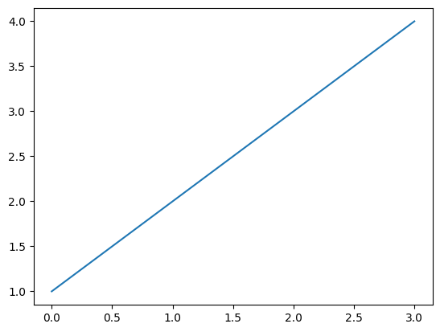

```python
plt.plot([1,2,3,4]);
```

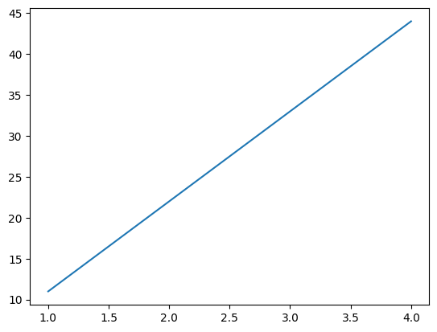

```python
x = [1,2,3,4]
y = [11,22,33,44]
plt.plot(x,y);
```

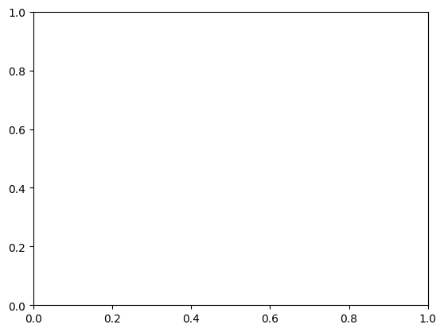

```python
# 1st method
fig = plt.figure() #creates a figure
ax = fig.add_subplot() #adds some axes
plt.show()
```

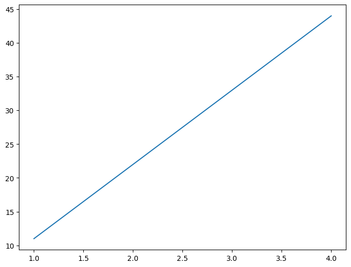

```python
# 2nd method
fig = plt.figure() #creates a figure
ax = fig.add_axes([1,1,1,1]) #adds some axes
ax.plot(x,y) #add some data
plt.show()
```

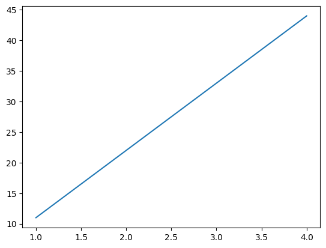

```python
# 3rd method (recommended)
fig, ax = plt.subplots()
ax.plot(x,y); #add some data
```

**Anatomy of a Matplotlib Plot**

- **Matplotlib Example Workflow**
0. Import Matplotlib and get it ready for plotting in Jupyter (if you are using Jupyter Notebok)
   - `%matplotlib inline`
   - `import matplotlib.pyplot as plt`
1. Prepare data
   - `x = [1,2,3,4]`
   - `y = [11,22,33,44]`
2. Setup plot
   - `fig, ax = plt.subplots(figsize=(10,10))` --> width and height of the plot (the dimensions of the plot)
3. Plot the data
   - `ax.plot(x,y)`
4. Customize plot
   - `ax.set(title='Simple Plot', xlabel='a-axis', ylabel='y-axis')`
5. Save and show
   - `fig.savefig('data/sample-plot.png')`

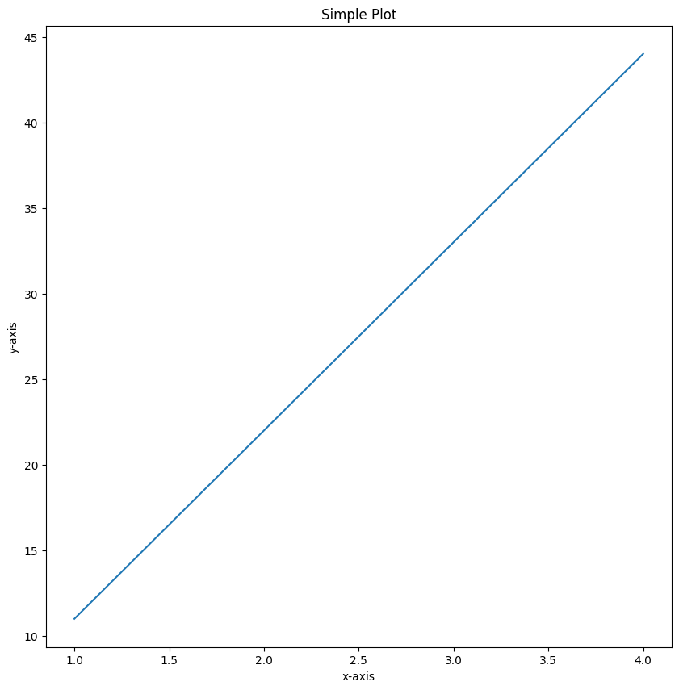

```python
import matplotlib.pyplot as plt
x = [1,2,3,4]
y = [11,22,33,44]

fig,ax = plt.subplots(figsize=(10,10))

ax.plot(x,y)

ax.set(title="Simple Plot", xlabel="x-axis", ylabel="y-axis")
fig.savefig('data/sample-plot.png')
```

```python
import numpy as np
x1 = np.random.randint(10, size=(5,3))
y2 = np.random.randint(8, size=(5,3))
```

```
[Text(0.5, 1.0, 'Simple Plot'), Text(0.5, 0, 'x-axis'), Text(0, 0.5, 'y-axis')]
```

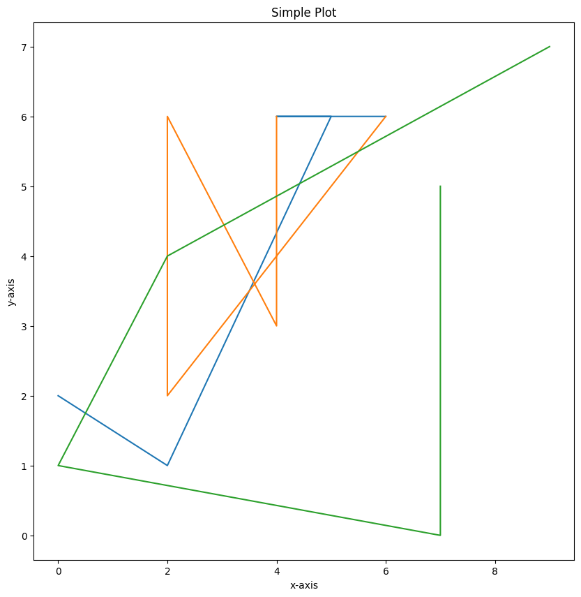

```python
#Example with the random numy arrays
import matplotlib.pyplot as plt

fig,ax = plt.subplots(figsize=(10,10))

ax.plot(x1,y2)

ax.set(title="Simple Plot", xlabel="x-axis", ylabel="y-axis")
```

#### Scatter Plot and Bar Plot

**Making figures with NumPy arrays**

```python
import numpy as np
```

```python
#Create some data

x = np.linspace(0,10,100)
x
```

```
array([ 0.        ,  0.1010101 ,  0.2020202 ,  0.3030303 ,  0.4040404 ,
        0.50505051,  0.60606061,  0.70707071,  0.80808081,  0.90909091,
        1.01010101,  1.11111111,  1.21212121,  1.31313131,  1.41414141,
        1.51515152,  1.61616162,  1.71717172,  1.81818182,  1.91919192,
        2.02020202,  2.12121212,  2.22222222,  2.32323232,  2.42424242,
        2.52525253,  2.62626263,  2.72727273,  2.82828283,  2.92929293,
        3.03030303,  3.13131313,  3.23232323,  3.33333333,  3.43434343,
        3.53535354,  3.63636364,  3.73737374,  3.83838384,  3.93939394,
        4.04040404,  4.14141414,  4.24242424,  4.34343434,  4.44444444,
        4.54545455,  4.64646465,  4.74747475,  4.84848485,  4.94949495,
        5.05050505,  5.15151515,  5.25252525,  5.35353535,  5.45454545,
        5.55555556,  5.65656566,  5.75757576,  5.85858586,  5.95959596,
        6.06060606,  6.16161616,  6.26262626,  6.36363636,  6.46464646,
        6.56565657,  6.66666667,  6.76767677,  6.86868687,  6.96969697,
        7.07070707,  7.17171717,  7.27272727,  7.37373737,  7.47474747,
        7.57575758,  7.67676768,  7.77777778,  7.87878788,  7.97979798,
        8.08080808,  8.18181818,  8.28282828,  8.38383838,  8.48484848,
        8.58585859,  8.68686869,  8.78787879,  8.88888889,  8.98989899,
        9.09090909,  9.19191919,  9.29292929,  9.39393939,  9.49494949,
        9.5959596 ,  9.6969697 ,  9.7979798 ,  9.8989899 , 10.        ])
```

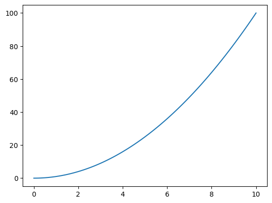

```python
#Plot the data and create a line plot
fig, ax = plt.subplots()
ax.plot(x, x**2);
```

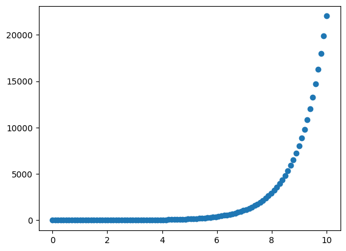

```python
#Use the same data for a scatter plot
fig, ax = plt.subplots()
ax.scatter(x, np.exp(x)); #using exponential of x just to plot the data
```

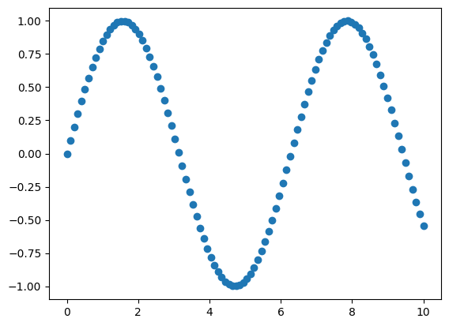

```python
#Another scatter plot
fig, ax = plt.subplots()
plt.scatter(x, np.sin(x));
```

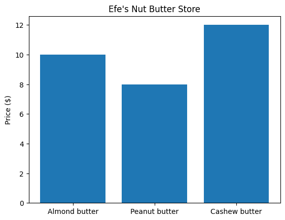

```python
# Make a bar plot from dictionary
nut_butter_prices = {"Almond butter": 10,
                     "Peanut butter": 8,
                     "Cashew butter": 12}

fig, ax = plt.subplots()
ax.bar(nut_butter_prices.keys(), nut_butter_prices.values())
ax.set(title = "Efe's Nut Butter Store", ylabel="Price ($)"); #just customizing the plot
```

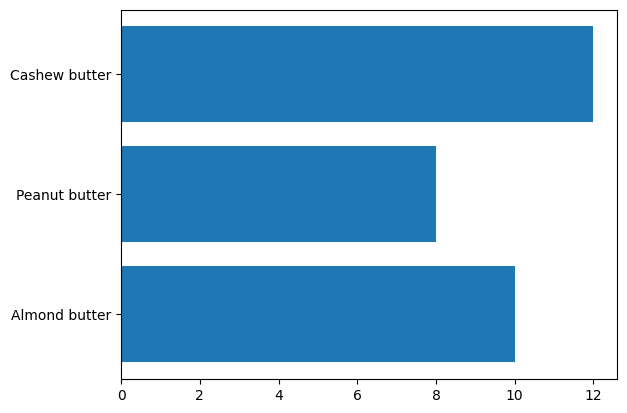

```python
#horizontal bar plot
fig, ax = plt.subplots()
ax.barh(nut_butter_prices.keys(), nut_butter_prices.values());
```

#### Histogram and Subplots

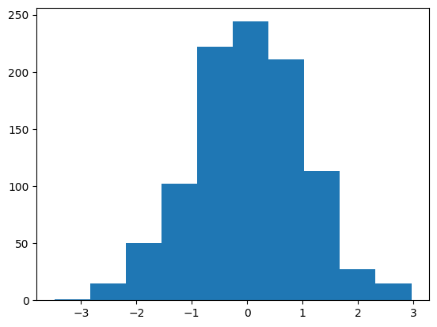

```python
#Histograms

x = np.random.randn(1000)
fig, ax = plt.subplots()
ax.hist(x);
```

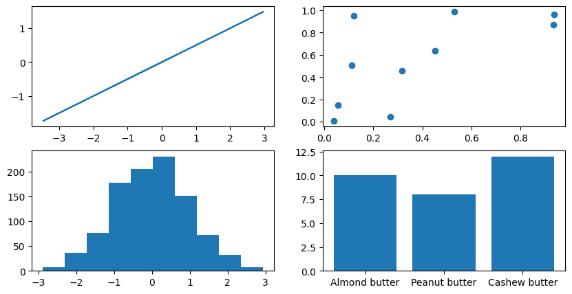

```python
#Plots happening at the same time subplots
##Two options for subplots
###Option 1

fig, ((ax1, ax2), (ax3, ax4)) = plt.subplots(nrows=2, ncols=2, figsize=(10,5))

#Plot to each different axis
ax1.plot(x , x/2);
ax2.scatter(np.random.random(10), np.random.random(10));
ax3.hist(np.random.randn(1000));
ax4.bar(nut_butter_prices.keys(), nut_butter_prices.values());
```

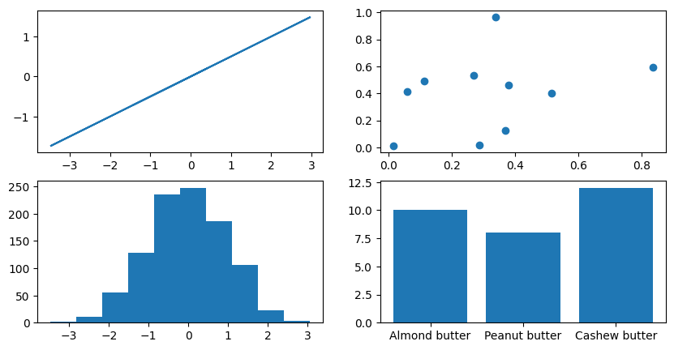

```python
#Subplots Option 2
fig, ax = plt.subplots(nrows=2, ncols=2, figsize=(10,5))

#Plot to each different index
ax[0,0].plot(x, x/2); #this is the same as ax1
ax[0,1].scatter(np.random.random(10), np.random.random(10)); #this is the same as ax2
ax[1,0].hist(np.random.randn(1000)); #this is the same as ax3
ax[1,1].bar(nut_butter_prices.keys(), nut_butter_prices.values()); #this is the same as ax4
```

#### Plotting from Pandas DataFrames

```python
import pandas as pd
```

```python
# make a dataframe

car_sales = pd.read_csv("data/car-sales.csv")
```

```python
car_sales
```

|  | Make | Colour | Odometer (KM) | Doors | Price |
| --- | --- | --- | --- | --- | --- |
| 0 | Toyota | White | 150043 | 4 | $4,000.00 |
| 1 | Honda | Red | 87899 | 4 | $5,000.00 |
| 2 | Toyota | Blue | 32549 | 3 | $7,000.00 |
| 3 | BMW | Black | 11179 | 5 | $22,000.00 |
| 4 | Nissan | White | 213095 | 4 | $3,500.00 |
| 5 | Toyota | Green | 99213 | 4 | $4,500.00 |
| 6 | Honda | Blue | 45698 | 4 | $7,500.00 |
| 7 | Honda | Blue | 54738 | 4 | $7,000.00 |
| 8 | Toyota | White | 60000 | 4 | $6,250.00 |
| 9 | Nissan | White | 31600 | 4 | $9,700.00 |

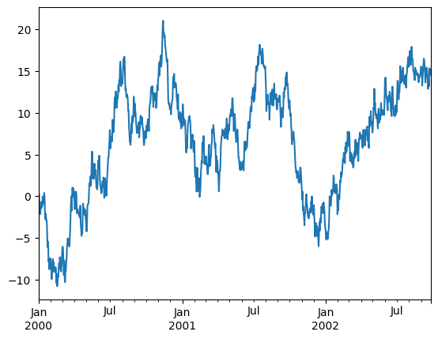

```python
#An example code for matplotlib and pandas

ts = pd.Series(np.random.randn(1000),index=pd.date_range('1/1/2000', periods=1000))

ts = ts.cumsum()
ts.plot()
```

```python
#Format the price column first

car_sales["Price"] = car_sales["Price"].str.replace('[\$\,\.]', '', regex=True).astype(int) #this will remove the $ and the , and change the data type to int
car_sales
```

|  | Make | Colour | Odometer (KM) | Doors | Price |
| --- | --- | --- | --- | --- | --- |
| 0 | Toyota | White | 150043 | 4 | 400000 |
| 1 | Honda | Red | 87899 | 4 | 500000 |
| 2 | Toyota | Blue | 32549 | 3 | 700000 |
| 3 | BMW | Black | 11179 | 5 | 2200000 |
| 4 | Nissan | White | 213095 | 4 | 350000 |
| 5 | Toyota | Green | 99213 | 4 | 450000 |
| 6 | Honda | Blue | 45698 | 4 | 750000 |
| 7 | Honda | Blue | 54738 | 4 | 700000 |
| 8 | Toyota | White | 60000 | 4 | 625000 |
| 9 | Nissan | White | 31600 | 4 | 970000 |

```python
#remove the zeros
car_sales["Price"] = car_sales["Price"] / 100
```

```python
car_sales
```

|  | Make | Colour | Odometer (KM) | Doors | Price |
| --- | --- | --- | --- | --- | --- |
| 0 | Toyota | White | 150043 | 4 | 4000.0 |
| 1 | Honda | Red | 87899 | 4 | 5000.0 |
| 2 | Toyota | Blue | 32549 | 3 | 7000.0 |
| 3 | BMW | Black | 11179 | 5 | 22000.0 |
| 4 | Nissan | White | 213095 | 4 | 3500.0 |
| 5 | Toyota | Green | 99213 | 4 | 4500.0 |
| 6 | Honda | Blue | 45698 | 4 | 7500.0 |
| 7 | Honda | Blue | 54738 | 4 | 7000.0 |
| 8 | Toyota | White | 60000 | 4 | 6250.0 |
| 9 | Nissan | White | 31600 | 4 | 9700.0 |

```python
# Add a sale date column

car_sales["Sale Date"] = pd.date_range("1/1/2020", periods=len(car_sales))
car_sales
```

|  | Make | Colour | Odometer (KM) | Doors | Price | Sale Date |
| --- | --- | --- | --- | --- | --- | --- |
| 0 | Toyota | White | 150043 | 4 | 4000.0 | 2020-01-01 |
| 1 | Honda | Red | 87899 | 4 | 5000.0 | 2020-01-02 |
| 2 | Toyota | Blue | 32549 | 3 | 7000.0 | 2020-01-03 |
| 3 | BMW | Black | 11179 | 5 | 22000.0 | 2020-01-04 |
| 4 | Nissan | White | 213095 | 4 | 3500.0 | 2020-01-05 |
| 5 | Toyota | Green | 99213 | 4 | 4500.0 | 2020-01-06 |
| 6 | Honda | Blue | 45698 | 4 | 7500.0 | 2020-01-07 |
| 7 | Honda | Blue | 54738 | 4 | 7000.0 | 2020-01-08 |
| 8 | Toyota | White | 60000 | 4 | 6250.0 | 2020-01-09 |
| 9 | Nissan | White | 31600 | 4 | 9700.0 | 2020-01-10 |

```python
#making a total column to show the total money we are making every time we sell a car
car_sales["Total Sales"] = car_sales["Price"].cumsum()
car_sales
```

|  | Make | Colour | Odometer (KM) | Doors | Price | Sale Date | Total Sales |
| --- | --- | --- | --- | --- | --- | --- | --- |
| 0 | Toyota | White | 150043 | 4 | 4000.0 | 2020-01-01 | 4000.0 |
| 1 | Honda | Red | 87899 | 4 | 5000.0 | 2020-01-02 | 9000.0 |
| 2 | Toyota | Blue | 32549 | 3 | 7000.0 | 2020-01-03 | 16000.0 |
| 3 | BMW | Black | 11179 | 5 | 22000.0 | 2020-01-04 | 38000.0 |
| 4 | Nissan | White | 213095 | 4 | 3500.0 | 2020-01-05 | 41500.0 |
| 5 | Toyota | Green | 99213 | 4 | 4500.0 | 2020-01-06 | 46000.0 |
| 6 | Honda | Blue | 45698 | 4 | 7500.0 | 2020-01-07 | 53500.0 |
| 7 | Honda | Blue | 54738 | 4 | 7000.0 | 2020-01-08 | 60500.0 |
| 8 | Toyota | White | 60000 | 4 | 6250.0 | 2020-01-09 | 66750.0 |
| 9 | Nissan | White | 31600 | 4 | 9700.0 | 2020-01-10 | 76450.0 |

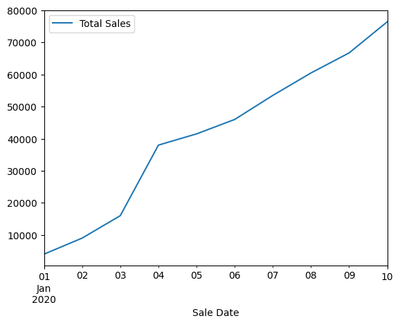

```python
# Let's plot the total sales
car_sales.plot(x="Sale Date", y = "Total Sales");
```

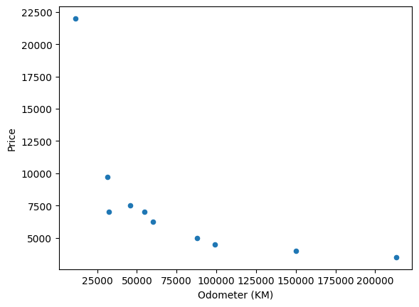

```python
#Scatter plot
car_sales.plot(x="Odometer (KM)", y="Price", kind="scatter");
```

```python
#how about a bar graph
x = np.random.rand(10,4)
x
#Turn it into a dataframe

df = pd.DataFrame(x, columns=['a', 'b', 'c' , 'd'])
df
```

|  | a | b | c | d |
| --- | --- | --- | --- | --- |
| 0 | 0.474309 | 0.168020 | 0.354797 | 0.399983 |
| 1 | 0.057392 | 0.583307 | 0.884343 | 0.151743 |
| 2 | 0.597808 | 0.664739 | 0.419335 | 0.701098 |
| 3 | 0.410732 | 0.504637 | 0.007353 | 0.691720 |
| 4 | 0.661343 | 0.038401 | 0.368250 | 0.979032 |
| 5 | 0.420737 | 0.501945 | 0.909930 | 0.717262 |
| 6 | 0.582070 | 0.797805 | 0.864366 | 0.456888 |
| 7 | 0.475108 | 0.386051 | 0.966706 | 0.697166 |
| 8 | 0.083223 | 0.862960 | 0.480560 | 0.068754 |
| 9 | 0.549717 | 0.417164 | 0.877749 | 0.203995 |

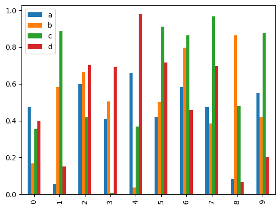

```python
df.plot.bar();
```

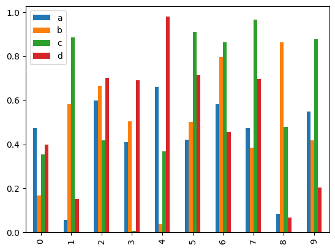

```python
df.plot(kind="bar"); #same thing as above
```

```python
car_sales
```

|  | Make | Colour | Odometer (KM) | Doors | Price | Sale Date | Total Sales |
| --- | --- | --- | --- | --- | --- | --- | --- |
| 0 | Toyota | White | 150043 | 4 | 4000.0 | 2020-01-01 | 4000.0 |
| 1 | Honda | Red | 87899 | 4 | 5000.0 | 2020-01-02 | 9000.0 |
| 2 | Toyota | Blue | 32549 | 3 | 7000.0 | 2020-01-03 | 16000.0 |
| 3 | BMW | Black | 11179 | 5 | 22000.0 | 2020-01-04 | 38000.0 |
| 4 | Nissan | White | 213095 | 4 | 3500.0 | 2020-01-05 | 41500.0 |
| 5 | Toyota | Green | 99213 | 4 | 4500.0 | 2020-01-06 | 46000.0 |
| 6 | Honda | Blue | 45698 | 4 | 7500.0 | 2020-01-07 | 53500.0 |
| 7 | Honda | Blue | 54738 | 4 | 7000.0 | 2020-01-08 | 60500.0 |
| 8 | Toyota | White | 60000 | 4 | 6250.0 | 2020-01-09 | 66750.0 |
| 9 | Nissan | White | 31600 | 4 | 9700.0 | 2020-01-10 | 76450.0 |

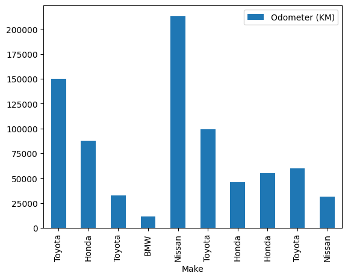

```python
car_sales.plot(x="Make", y="Odometer (KM)", kind='bar');
```

```python
#How about histograms?
car_sales["Odometer (KM)"].plot.hist();
```

[output not shown]

```python
car_sales["Odometer (KM)"].plot(kind="hist"); #the same as above, just a different way of writing it
```

[output not shown]

```python
car_sales["Odometer (KM)"].plot.hist(bins=10); #with bins parameter you decide how many bins you want. If you change it the thickness of the bars will change
```

[output not shown]

```python
#Let's try on another dataset
heart_disease = pd.read_csv("data/heart-disease.csv")
heart_disease
```

|  | age | sex | cp | trestbps | chol | fbs | restecg | thalach | exang | oldpeak | slope | ca | thal | target |
| --- | --- | --- | --- | --- | --- | --- | --- | --- | --- | --- | --- | --- | --- | --- |
| 0 | 63 | 1 | 3 | 145 | 233 | 1 | 0 | 150 | 0 | 2.3 | 0 | 0 | 1 | 1 |
| 1 | 37 | 1 | 2 | 130 | 250 | 0 | 1 | 187 | 0 | 3.5 | 0 | 0 | 2 | 1 |
| 2 | 41 | 0 | 1 | 130 | 204 | 0 | 0 | 172 | 0 | 1.4 | 2 | 0 | 2 | 1 |
| 3 | 56 | 1 | 1 | 120 | 236 | 0 | 1 | 178 | 0 | 0.8 | 2 | 0 | 2 | 1 |
| 4 | 57 | 0 | 0 | 120 | 354 | 0 | 1 | 163 | 1 | 0.6 | 2 | 0 | 2 | 1 |
| ... | ... | ... | ... | ... | ... | ... | ... | ... | ... | ... | ... | ... | ... | ... |
| 298 | 57 | 0 | 0 | 140 | 241 | 0 | 1 | 123 | 1 | 0.2 | 1 | 0 | 3 | 0 |
| 299 | 45 | 1 | 3 | 110 | 264 | 0 | 1 | 132 | 0 | 1.2 | 1 | 0 | 3 | 0 |
| 300 | 68 | 1 | 0 | 144 | 193 | 1 | 1 | 141 | 0 | 3.4 | 1 | 2 | 3 | 0 |
| 301 | 57 | 1 | 0 | 130 | 131 | 0 | 1 | 115 | 1 | 1.2 | 1 | 1 | 3 | 0 |
| 302 | 57 | 0 | 1 | 130 | 236 | 0 | 0 | 174 | 0 | 0.0 | 1 | 1 | 2 | 0 |

303 rows × 14 columns

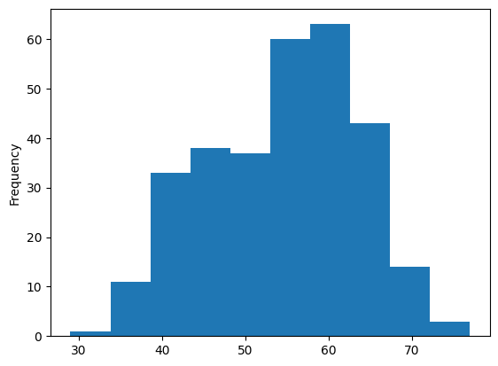

```python
#Create a histogram of age
heart_disease["age"].plot.hist(bins=10);
```

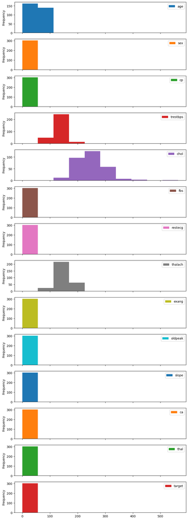

```python
heart_disease.plot.hist(subplots=True, figsize=(10,30)); #this will show the histograms of all the columns
```

```python
## Which one should you use? (pyplot vs matplotlib OO method)

## When plotting something quickly, okay to use the pyplot method
## When plotting something more advanced, use the OO method

over_50 = heart_disease[heart_disease["age"] > 50]
over_50
```

|  | age | sex | cp | trestbps | chol | fbs | restecg | thalach | exang | oldpeak | slope | ca | thal | target |
| --- | --- | --- | --- | --- | --- | --- | --- | --- | --- | --- | --- | --- | --- | --- |
| 0 | 63 | 1 | 3 | 145 | 233 | 1 | 0 | 150 | 0 | 2.3 | 0 | 0 | 1 | 1 |
| 3 | 56 | 1 | 1 | 120 | 236 | 0 | 1 | 178 | 0 | 0.8 | 2 | 0 | 2 | 1 |
| 4 | 57 | 0 | 0 | 120 | 354 | 0 | 1 | 163 | 1 | 0.6 | 2 | 0 | 2 | 1 |
| 5 | 57 | 1 | 0 | 140 | 192 | 0 | 1 | 148 | 0 | 0.4 | 1 | 0 | 1 | 1 |
| 6 | 56 | 0 | 1 | 140 | 294 | 0 | 0 | 153 | 0 | 1.3 | 1 | 0 | 2 | 1 |
| ... | ... | ... | ... | ... | ... | ... | ... | ... | ... | ... | ... | ... | ... | ... |
| 297 | 59 | 1 | 0 | 164 | 176 | 1 | 0 | 90 | 0 | 1.0 | 1 | 2 | 1 | 0 |
| 298 | 57 | 0 | 0 | 140 | 241 | 0 | 1 | 123 | 1 | 0.2 | 1 | 0 | 3 | 0 |
| 300 | 68 | 1 | 0 | 144 | 193 | 1 | 1 | 141 | 0 | 3.4 | 1 | 2 | 3 | 0 |
| 301 | 57 | 1 | 0 | 130 | 131 | 0 | 1 | 115 | 1 | 1.2 | 1 | 1 | 3 | 0 |
| 302 | 57 | 0 | 1 | 130 | 236 | 0 | 0 | 174 | 0 | 0.0 | 1 | 1 | 2 | 0 |

208 rows × 14 columns

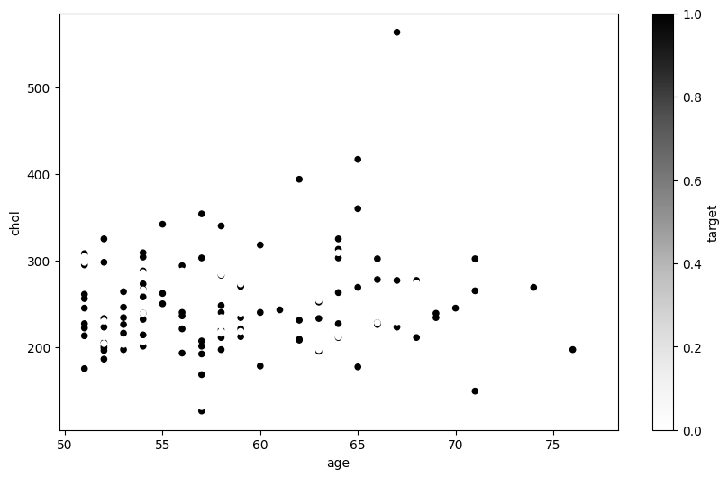

```python
#pyplot method
over_50.plot(kind="scatter", x = "age", y = "chol", c = "target", figsize=(10,6));
```